# Geographically weighted regressions for prioritizing educational planning, policies, and interventions - Supporting code

Note that the information used for the construction of this example is available free of charge, but a permission needs to be requested by emailing datoscede@uniandes.edu.co. Open receiving permission from this email, it can be forwarded to development@iiep.unesco.org, and the password for accessing to the folder will be provided. For more information on the data source, visit https://datoscede.uniandes.edu.co/es/catalogo-de-microdata

Installing all the packages that will be needed, and loading them into the R kernel. Note that install.packages has been commented out, and should be uncommented as needed.

```r
options(warn = -1)
#install.packages("GWmodel")
library("GWmodel")
#install.packages("gwrr")
library("gwrr")
#install.packages("sp")
library("sp")
#install.packages("gstat")
library("gstat")
#install.packages("ModelMap")
library("ModelMap")
#install.packages("RColorBrewer")
library("RColorBrewer")
#install.packages("ape")
library("ape")
#install.packages("usdm")
library("usdm")
#install.packages("rgdal")
library("rgdal")
#install.packages("tidyr")
library("tidyr")
#install.packages("MASS")
library("MASS")
#install.packages("Compositional")
library("Compositional")
#install.packages("dplyr")
library("dplyr")
#install.packages("spatialEco")
library("spatialEco")
#install.packages("broom")
library("broom")
```

Determining the working directory, which should have the same structure as the one found in in the Replication folder. This needs to be changes to the user's folder. Note that Windows uses backslashed (), while Mac uses forward-slash (/). The code needs to be changed accordingly.

```r
setwd("C:\\Users\\g.vargas\\BOX\\IIEP_MyProjects\\MP_01000298_RND_SDA\\WorkFiles_Experts\\298-Issue-Papers\\298-Issue-Paper-GWR\\Replication files")
```

### Importing the data extracted from QGIS

Note that the file should be saved under the Data\Colombia folder.

```r
PolygonShape <- readOGR(dsn = "Data\\Colombia", layer = "GWR - Colombia", drop_unsupported_fields=FALSE, disambiguateFIDs=TRUE)
cat(" ")
cat("The final names of the variables that were imported are the following:")

colnames(PolygonShape@data)
```

```
 The final names of the variables that were imported are the following:
```

1. 'fid'

2. 'admin0Name'

3. 'admin0Pcod'

4. 'admin1Name'

5. 'admin1Pcod'

6. 'admin2Name'

7. 'admin2Pcod'

8. 'admin2RefN'

9. 'admin2AltN'

10. 'admin2Al_1'

11. 'date'

12. 'validOn'

13. 'validTo'

14. 'Shape_Leng'

15. 'Shape_Area'

16. 'Key'

17. 'Long'

18. 'Lat'

19. 'MurderRate'

20. 'Poverty'

21. 'ProxyGDP'

22. 'ICFES_GPI'

23. 'TransEducP'

24. 'TransAlimE'

25. 'SISBEN1PC'

26. 'CV_fid'

27. 'CV_ano'

28. 'CV_Violenc'

29. 'CV_conflic'

30. 'CV_confl_1'

31. 'CV_confl_2'

32. 'CV_poblind'

33. 'CV_ocupesp'

34. 'CV_asalt_p'

35. 'CV_incur_p'

36. 'CV_terrori'

37. 'CV_secuest'

38. 'CV_pirater'

39. 'CV_reten_i'

40. 'CV_hostig_'

41. 'CV_ataq_in'

42. 'CV_ataq_ae'

43. 'CV_acc_sub'

44. 'CV_embosca'

45. 'CV_cont_ar'

46. 'CV_homic_v'

47. 'CV_homic_c'

48. 'CV_homicid'

49. 'CV_homi_tr'

50. 'CV_captura'

51. 'CV_captu_G'

52. 'CV_captu_E'

53. 'CV_captu_F'

54. 'CV_coca'

55. 'CV_o_amena'

56. 'CV_o_despl'

57. 'CV_d_amena'

58. 'CV_d_despl'

59. 'CV_desplaz'

60. 'CV_despl_1'

61. 'CV_hurto_p'

62. 'CV_hurto_r'

63. 'CV_hurto_a'

64. 'CV_hurto_m'

65. 'CV_hurto_c'

66. 'CV_hurto_e'

67. 'CV_hurto_v'

68. 'CV_hurto'

69. 'E_fid'

70. 'E_ano'

71. 'E_pobsimpl'

72. 'E_pobsim_1'

73. 'E_t_establ'

74. 'E_t_esta_1'

75. 'E_t_esta_2'

76. 'E_jornada_'

77. 'E_jornad_1'

78. 'E_jornad_2'

79. 'E_jornad_3'

80. 'E_jornad_4'

81. 'E_jornad_5'

82. 'E_jornad_6'

83. 'E_jornad_7'

84. 'E_jornad_8'

85. 'E_admin_to'

86. 'E_admin__1'

87. 'E_admin__2'

88. 'E_admin__3'

89. 'E_admin_m'

90. 'E_admin_h'

91. 'E_docen_to'

92. 'E_docen_of'

93. 'E_docen_ru'

94. 'E_docen_ur'

95. 'E_docen_pr'

96. 'E_docen__1'

97. 'E_docen_se'

98. 'E_docen_me'

99. 'E_docen_mp'

100. 'E_docen__2'

101. 'E_docen_ms'

102. 'E_docen_mm'

103. 'E_docen_hp'

104. 'E_docen__3'

105. 'E_docen_hs'

106. 'E_docen_hm'

107. 'E_alumn_to'

108. 'E_alumn_of'

109. 'E_alumn_ru'

110. 'E_alumn_ur'

111. 'E_alumn_pr'

112. 'E_alumn__1'

113. 'E_alumn_se'

114. 'E_alumn_me'

115. 'E_alumn__2'

116. 'E_alumn__3'

117. 'E_alumn__4'

118. 'E_alumn__5'

119. 'E_alumn__6'

120. 'E_alumn__7'

121. 'E_alumn__8'

122. 'E_alumn__9'

123. 'E_alumn_10'

124. 'E_alumn_11'

125. 'E_alumn_12'

126. 'E_alumn_13'

127. 'E_alumn_mp'

128. 'E_alumn_14'

129. 'E_alumn_ms'

130. 'E_alumn_mm'

131. 'E_alumn_mj'

132. 'E_alumn_hp'

133. 'E_alumn_15'

134. 'E_alumn_hs'

135. 'E_alumn_hm'

136. 'E_alumn_hj'

137. 'E_s11_tota'

138. 'E_s11_mate'

139. 'E_s11_soci'

140. 'E_s11_cien'

141. 'E_s11_lect'

142. 'E_s11_ingl'

143. 'E_s11_to_1'

144. 'E_s11_to_2'

145. 'E_s11_to_3'

146. 'E_s11_to_4'

147. 'E_s11_to_5'

148. 'E_s11_to_6'

149. 'E_s11_to_7'

150. 'E_s11_to_8'

151. 'E_s11_to_9'

152. 'E_s11_to10'

153. 'E_s11_to11'

154. 'E_s11_to12'

155. 'E_s11_to13'

156. 'E_s11_to14'

157. 'E_s11_to15'

158. 'E_s11_to16'

159. 'E_s11_to17'

160. 'E_s11_to18'

161. 'E_n_icfes'

162. 'E_col_tota'

163. 'E_col_to_1'

164. 'E_col_to_2'

165. 'E_col_B'

166. 'E_col_C'

167. 'E_col_D'

168. 'E_col_B_o'

169. 'E_col_C_o'

170. 'E_col_D_o'

171. 'E_col_B_ca'

172. 'E_col_C_ca'

173. 'E_col_D_ca'

174. 'GC_fid'

175. 'GC_coddept'

176. 'GC_codprov'

177. 'GC_depto'

178. 'GC_provinc'

179. 'GC_municip'

180. 'GC_ano'

181. 'GC_ao_crea'

182. 'GC_act_adm'

183. 'GC_gandina'

184. 'GC_gcaribe'

185. 'GC_gpacifi'

186. 'GC_gorinoq'

187. 'GC_gamazon'

188. 'GC_pobl_ru'

189. 'GC_pobl_ur'

190. 'GC_pobl_to'

191. 'GC_indrura'

192. 'GC_sisben3'

193. 'GC_sisbe_1'

194. 'GC_sisbe_2'

195. 'GC_sisbe_3'

196. 'GC_sisbe_4'

197. 'GC_sisbe_5'

198. 'GC_sisbe_6'

199. 'GC_sisbe_7'

200. 'GC_sisbe_8'

201. 'GC_sisbe_9'

202. 'GC_areaofi'

203. 'GC_areao_1'

204. 'GC_altura'

205. 'GC_discapi'

206. 'GC_dismdo'

207. 'GC_disbogo'

208. 'GC_codmdo'

209. 'GC_mercado'

210. 'GC_distanc'

211. 'G_fid'

212. 'G_ano'

213. 'G_y_total'

214. 'G_y_corr'

215. 'G_y_corr_t'

216. 'G_y_corr_1'

217. 'G_y_corr_2'

218. 'G_y_corr_3'

219. 'G_y_corr_4'

220. 'G_y_no_tri'

221. 'G_y_transf'

222. 'G_y_tran_1'

223. 'G_y_tran_2'

224. 'G_g_total'

225. 'G_g_corr'

226. 'G_g_func'

227. 'G_g_func_p'

228. 'G_g_func_g'

229. 'G_g_func_t'

230. 'G_g_int_de'

231. 'G_deficit'

232. 'G_y_cap'

233. 'G_y_cap_re'

234. 'G_y_cap_tr'

235. 'G_y_cap_co'

236. 'G_y_cap_ot'

237. 'G_g_cap'

238. 'G_g_cap_FB'

239. 'G_g_cap_re'

240. 'G_deficit_'

241. 'G_finan'

242. 'G_finan_cr'

243. 'G_finan__1'

244. 'G_finan__2'

245. 'G_finan__3'

246. 'G_DF_ing_f'

247. 'G_DF_deuda'

248. 'G_DF_ing_t'

249. 'G_DF_ing_p'

250. 'G_DF_gast_'

251. 'G_DF_ahorr'

252. 'G_DF_desem'

253. 'G_DF_p_nal'

254. 'G_DI_efica'

255. 'G_DI_efici'

256. 'G_DI_rlega'

257. 'G_DI_capad'

258. 'G_DI_gesti'

259. 'G_DI_desem'

260. 'G_DI_rango'

261. 'G_DI_p_nal'

262. 'G_categori'

263. 'G_SGP_tota'

264. 'G_SGP_educ'

265. 'G_SGP_ed_1'

266. 'G_SGP_ed_2'

267. 'G_SGP_ed_3'

268. 'G_SGP_ed_4'

269. 'G_SGP_salu'

270. 'G_SGP_sa_1'

271. 'G_SGP_sa_2'

272. 'G_SGP_sa_3'

273. 'G_SGP_agua'

274. 'G_SGP_prop'

275. 'G_SGP_pr_1'

276. 'G_SGP_pr_2'

277. 'G_SGP_pr_3'

278. 'G_SGP_pr_4'

279. 'G_SGP_pr_5'

280. 'G_SGP_alim'

281. 'G_SGP_ribe'

282. 'G_SGP_resg'

283. 'G_SGP_fp'

284. 'G_SGP_pinf'

285. 'G_IGA_tota'

286. 'G_IGA_org_'

287. 'G_IGA_cont'

288. 'G_IGA_meci'

289. 'G_IGA_co_1'

290. 'G_IGA_gest'

291. 'G_IGA_exp_'

292. 'G_IGA_visi'

293. 'G_IGA_co_2'

294. 'G_IGA_plan'

295. 'G_IGA_comp'

296. 'G_IGA_sui'

297. 'G_IGA_sisb'

298. 'G_IGA_sima'

299. 'G_IGA_sist'

300. 'G_IGA_fut'

301. 'G_IGA_rega'

302. 'G_IGA_sice'

303. 'G_IGA_siga'

304. 'G_IGA_sige'

305. 'G_IGA_dial'

306. 'G_IGA_gobi'

307. 'G_IGA_gel_'

308. 'G_IGA_ge_1'

309. 'G_IGA_sece'

310. 'G_IGA_si_1'

311. 'G_IGA_suit'

312. 'G_IGA_tran'

313. 'G_IGA_si_2'

314. 'G_IGA_si_3'

315. 'G_IGA_si_4'

316. 'G_IGA_si_5'

317. 'G_IGA_aten'

318. 'G_IGA_si_6'

319. 'HS_fid'

320. 'HS_Aï..o'

321. 'HS_Nï..mer'

322. 'HS_Cobertu'

323. 'HS_Nï..m_1'

324. 'HS_Nï..m_2'

325. 'HS_Nï..m_3'

326. 'HS_Nï..m_4'

327. 'HS_Cober_1'

328. 'HS_Cober_2'

329. 'HS_Cober_3'

330. 'HS_Cober_4'

331. 'HS_Cober_5'

332. 'HS_Cober_6'

333. 'HS_Cober_7'

334. 'HS_Cober_8'

335. 'HS_Cober_9'

336. 'HS_Registr'

337. 'HS_Usuario'

338. 'HS_Usuar_1'

339. 'HS_Total.d'

340. 'HS_Cober10'

341. 'HS_Cober11'

342. 'Vulnerabil'

343. 'Threat'

344. 'Lack_Respo'

345. 'INFORM'

## 3. Model definition and selection of variables

Note that if the user already possess a strong conceptual framework which suggest a model specification, this step can be ommited.

Include in ListVariables all the variables to test in the model selection process, starting by the dependent variable. Make sure the names of the variables typed below match exactly with those presented above.

```r
ListVariables <- list("E_s11_to_1", "MurderRate", "ProxyGDP", "Poverty", "SISBEN1PC", "GC_indrura", "Vulnerabil", "Threat", "Lack_Respo", "TransEducP", "TransAlimE", "HS_Cober_7", "HS_Cober_1", "G_IGA_tota", "GC_discapi")
```

Given that the calculations produced below require a complete database (with no missing values), all rows that contain missing values for the list of variables specified above are removed.

```r
PolygonShapeTrimmed <- PolygonShape[c("Lat", "Long", "admin2Pcod", "E_s11_to_1", "SISBEN1PC", "MurderRate", "ProxyGDP", "Poverty", "GC_indrura", "Vulnerabil", "Threat", "Lack_Respo", "TransEducP", "TransAlimE", "HS_Cober_7", "HS_Cober_1", "G_IGA_tota", "GC_discapi")]
PolygonShapeTrimmed <- sp.na.omit(PolygonShapeTrimmed)
```

[output not shown]

[output not shown]

[output cut: 155 more lines]

[output not shown]

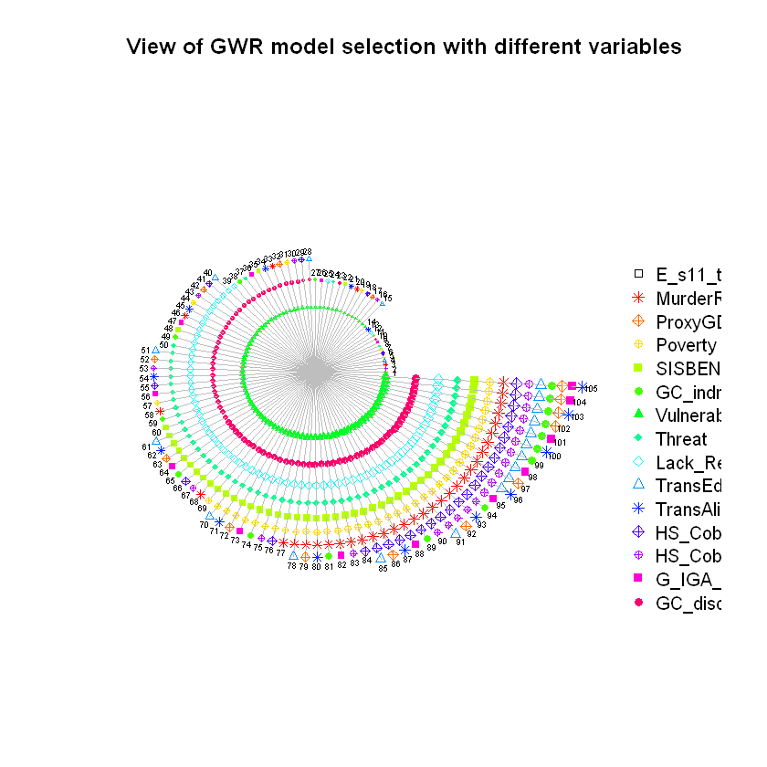

```r
DeVar <- ListVariables[[1]]
InDeVars <- unlist(ListVariables[2:length(ListVariables)], recursive = TRUE, use.names = FALSE)

model.sel <- model.selection.gwr(DeVar ,InDeVars, data = PolygonShapeTrimmed,
                                 kernel = "bisquare", adaptive = TRUE, bw = 80)
sorted.models <- model.sort.gwr(model.sel, numVars = length(InDeVars),
                                ruler.vector = model.sel[[2]][,2])

model.list <- sorted.models[[1]]

model.view.gwr(DeVar, InDeVars, model.list = model.list)
```

Using the procedure for model selection, the code plots the progression of the modified Akaike Information Criteria as the different models are used. This step can also be omitted if a strong theoretical model is already chosen.

Note that if, when a large number of potential independent variables, the AIC curve flats out at a specific point, the user should check which were the variables that were included in the model before said brake point, and either manually modify the equation, or change the index of the sorted.models list to include only the wanted elements. For instance, if when including 50 variables the modified AIC graph flattens out after 15 variables, the model to be estimated in In [21], In [22], and In [27] should be changed from length(sorted.models[[1]]) to the list index that corresponds to the 15th variable chosen.

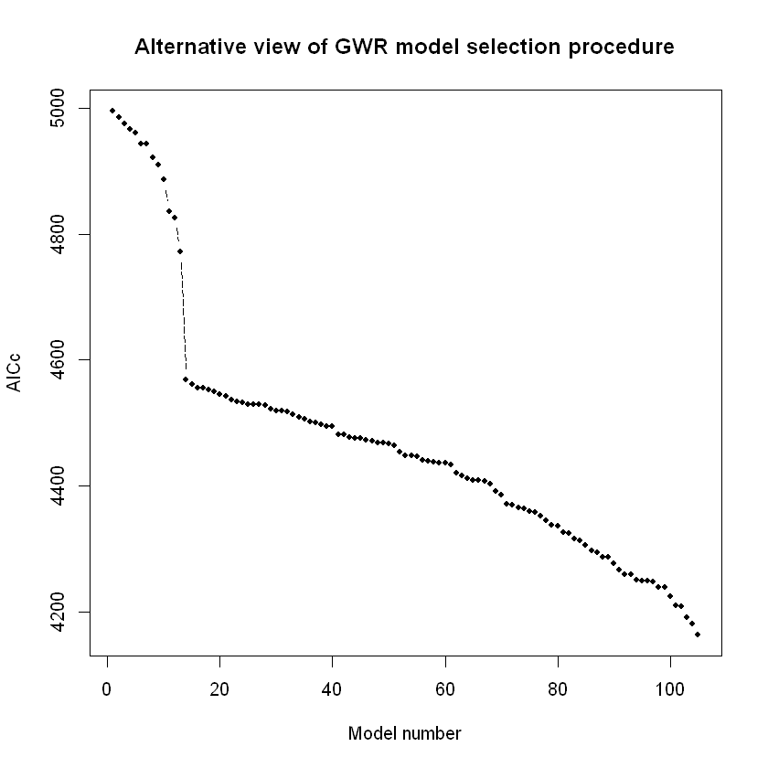

```r
plot(sorted.models[[2]][,2], col = "black", pch = 20, lty = 5,
     main = "Alternative view of GWR model selection procedure",
     ylab = "AICc", xlab = "Model number", type = "b")
```

## 4. Ordinary Least Squares

An initial OLS regression is performed with all the variables specified on the ListVariables list. Remember that the first element of said list should be the dependent variable, while the rest should be independent variables.

```r
attach(PolygonShapeTrimmed@data)
modelOLS <- lm(as.formula(sorted.models[[1]][[length(sorted.models[[1]])]][[1]]))
summary(modelOLS)
tidy_modelOLS <- tidy(modelOLS)
write.csv(tidy_modelOLS, "Tables\\ModelOLS.csv")
```

```
Call:
lm(formula = as.formula(sorted.models[[1]][[length(sorted.models[[1]])]][[1]]))

Residuals:
    Min      1Q  Median      3Q     Max
-7.9422 -1.6557 -0.0638  1.4837 10.8037

Coefficients:
              Estimate Std. Error t value Pr(>|t|)
(Intercept)  4.564e+01  9.593e-01  47.582  < 2e-16 ***
Vulnerabil  -6.474e-01  8.082e-02  -8.010 3.01e-15 ***
GC_discapi   2.757e-04  1.494e-03   0.185   0.8536
Lack_Respo  -5.360e-02  7.173e-02  -0.747   0.4551
Threat       1.207e-01  5.724e-02   2.108   0.0353 *
SISBEN1PC   -1.773e+01  3.871e+00  -4.580 5.20e-06 ***
Poverty      4.197e-02  7.559e-03   5.552 3.56e-08 ***
MurderRate  -1.156e-02  2.808e-03  -4.116 4.15e-05 ***
HS_Cober_7   5.764e-03  3.870e-03   1.489   0.1367
HS_Cober_1  -5.864e-03  3.409e-03  -1.720   0.0857 .
TransEducP   5.273e-07  1.091e-06   0.483   0.6289
GC_indrura   1.367e+00  4.869e-01   2.806   0.0051 **
ProxyGDP     3.229e-01  1.293e-01   2.498   0.0127 *
G_IGA_tota   6.908e-02  9.178e-03   7.527 1.11e-13 ***
TransAlimE  -2.082e-04  4.513e-05  -4.613 4.46e-06 ***
---
Signif. codes:  0 '***' 0.001 '**' 0.01 '*' 0.05 '.' 0.1 ' ' 1

Residual standard error: 2.458 on 1055 degrees of freedom
Multiple R-squared:  0.4969,	Adjusted R-squared:  0.4902
F-statistic: 74.41 on 14 and 1055 DF,  p-value: < 2.2e-16
```

## 5. Calculating Moran's I

A test for spatial autocorrelation, Moran's I, is performed. Here, the null hypothesis is that there is no spatial autocorrelation. A p-value under 0.05 will reject this hypothesis with a 95% of statistical confidence, in favor of the alternative hypothesis of the existance of spatial autocorrelation for the dependent variable. If this is the case, this means that the user should use GWR instead of OLS, since using OLS in the presence of spatial autocorrelation can lead to bias in the estimation of regression coefficients.

```r
DependentVariable <- c(ListVariables[[1]])
# MoransIListVariables <- c(ListVariables[[1]])
# MoransIListVariables <- append(MoransIListVariables, "Lat")
# MoransIListVariables <- append(MoransIListVariables, "Long")
PolygonShapeData <- PolygonShapeTrimmed@data
PolygonShapeData.dists <- as.matrix(dist(cbind(PolygonShapeData$Long, PolygonShapeData$Lat)))
PolygonShapeData.dists.inv <- 1/PolygonShapeData.dists
diag(PolygonShapeData.dists.inv) <- 0
Moran.I(PolygonShapeData$E_s11_to_1, PolygonShapeData.dists.inv, na.rm=FALSE)
```

**$observed**

0.140936788579202

**$expected**

-0.000935453695042095

**$sd**

0.0017834383152867

**$p.value**

0

### Obtaining summary statistics

This code computes a series of geographically weigthed summary statistics (GWSS), using different kernels for the conformation of the proximity matrix. In particular, the one below uses a boxcar distribution, which establishes a weight of 1 for observations where the distribution is within the radius defined by the bandwidth, and 0 otherwise. For more information, search help(gwss).

```r
# gw.ss.bx <- gwss(PolygonShapeTrimmed, PolygonShapeTrimmed, vars = c("E_s11_to_1", "MurderRate", "ProxyGDP", "Poverty"),
#                  kernel = "boxcar", adaptive = TRUE, bw = 48, quantile = TRUE)
gw.ss.bx <- gwss(PolygonShapeTrimmed, PolygonShapeTrimmed, vars = c(ListVariables),
                 kernel = "boxcar", adaptive = TRUE, bw = 48, quantile = TRUE)
```

The same summary statistics are obtained, now using a bi-square distribution, where the weigth of each surrounding observation is equal to (1-(vdist/bw)^2)^2 if the distance to the observation (vdist) is smaller than the bandwidth (bw), and 0 otherwise.

```r
# gw.ss.bs <- gwss(PolygonShapeTrimmed, PolygonShapeTrimmed, vars = c("E_s11_to_1", "MurderRate", "ProxyGDP", "Poverty"),
#                  kernel = "bisquare", adaptive = TRUE, bw = 48)
gw.ss.bs <- gwss(PolygonShapeTrimmed, PolygonShapeTrimmed, vars = c(ListVariables),
                 kernel = "bisquare", adaptive = TRUE, bw = 48)
```

The basic map layout is defined for the visualization of the GWSS.

```r
map.na = list("SpatialPolygonsRescale", layout.north.arrow(),
              offset = c(329000,261500), scale = 4000, col=1)
map.scale.1 = list("SpatialPolygonsRescale", layout.scale.bar(),
                   offset = c(326500,217000), scale = 5000, col=1, fill=c("transparent","blue"))
map.scale.2  = list("sp.text", c(326500,217900), "0", cex=0.9, col=1)
map.scale.3  = list("sp.text", c(331500,217900), "5km", cex=0.9, col=1)
map.layout <- list(map.na,map.scale.1,map.scale.2,map.scale.3)
```

Three main palettes are chosen, which can be costumized and adjusted as needed. More colors can be chosen from the options presented by inputing display.brewer.all()

```r
mypalette.1 <- brewer.pal(9, "Reds")
mypalette.2 <- brewer.pal(9, "Blues")
mypalette.3 <- brewer.pal(9, "Greens")
```

Preformatted variables are created for a number of variables selected. This can be further expanded if more variables want to be plotted.

```r
LSD_DepVar <- paste(ListVariables[[1]],"LSD", sep="_")
IQR_DepVar <- paste(ListVariables[[1]],"IQR", sep="_")
CorrDepVarIndVar1 <- paste("Corr",paste(ListVariables[[1]], ListVariables[[2]], sep="."), sep="_")
CorrDepVarIndVar2 <- paste("Corr",paste(ListVariables[[1]], ListVariables[[3]], sep="."), sep="_")
SpeRhoDepVarIndVar1 <- paste("Spearman_rho", paste(ListVariables[[1]], ListVariables[[2]], sep="."), sep="_")
SpeRhoDepVarIndVar3 <- paste("Spearman_rho", paste(ListVariables[[1]], ListVariables[[4]], sep="."), sep="_")
```

A map is constructed by using the shapefile already loaded into the program, and by using the geographically weigthed standard deviations of the dependent variable. An example using the actual name of the variable, as well as a more evident title for the graph, is presented as a comment.

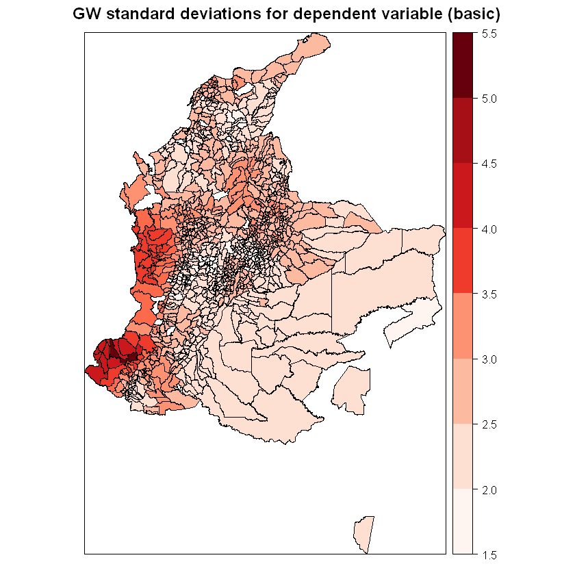

```r
# spplot(gw.ss.bx$SDF, "E_s11_to_1_LSD", key.space = "right",
#        col.regions = mypalette.1, cuts = 7,
#        main = "GW standard deviations for SABER11 (basic)", sp.layout = map.layout)
spplot(gw.ss.bx$SDF, LSD_DepVar, key.space = "right",
       col.regions = mypalette.1, pretty=TRUE, cuts=8,
       main = "GW standard deviations for dependent variable (basic)", sp.layout = map.layout)
```

The same map is created for the robust geographically weigthed inter-quartile ranges for the dependent variable, with its corresponding example.

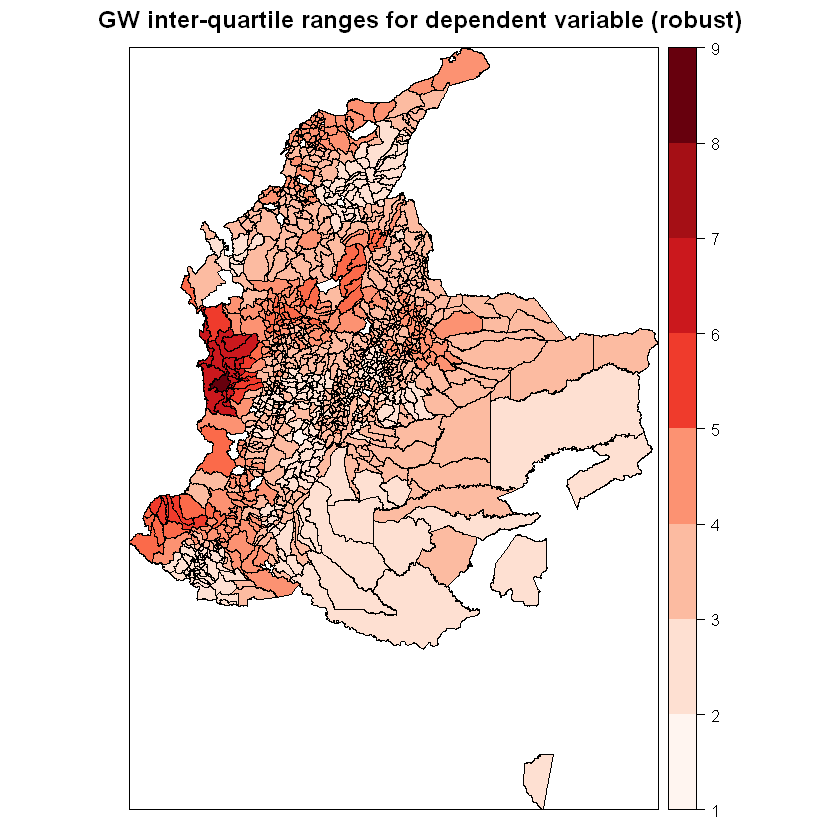

```r
# spplot(gw.ss.bx$SDF, "E_s11_to_1_IQR", key.space = "right",
#        col.regions = mypalette.1, cuts = 7,
#        main = "GW inter-quartile ranges for SABER11 (robust)",
#        sp.layout = map.layout)
spplot(gw.ss.bx$SDF, IQR_DepVar, key.space = "right",
       col.regions = mypalette.1, pretty=TRUE, cuts=8,
       main = "GW inter-quartile ranges for dependent variable (robust)",
       sp.layout = map.layout)
```

A map of GW correlations is shown between the dependent and the first independent variable, constructed using the box-car kernel described above.

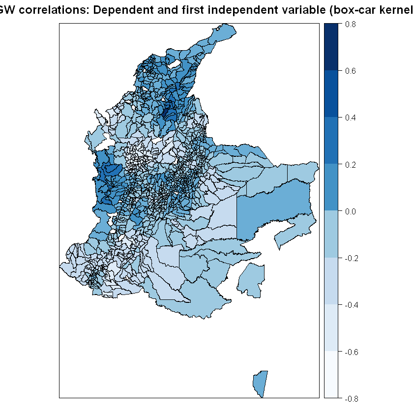

```r
# spplot(gw.ss.bx$SDF, "Corr_E_s11_to_1.MurderRate", key.space = "right",
#        col.regions = mypalette.2, at = c(-0.8, -0.6, -0.4, -0.2, 0, 0.2, 0.4, 0.6, 0.8, 1),
#        main = "GW correlations: SABER11 and MurderRate (box-car kernel)",
#        sp.layout = map.layout)
spplot(gw.ss.bx$SDF, CorrDepVarIndVar1, key.space = "right",
       col.regions = mypalette.2, pretty=TRUE, cuts=8,
       main = "GW correlations: Dependent and first independent variable (box-car kernel)",
       sp.layout = map.layout)
```

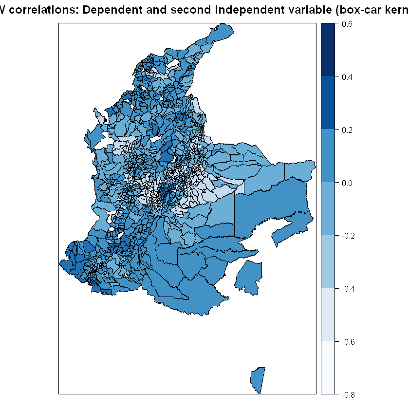

```r
# spplot(gw.ss.bx$SDF, "Corr_E_s11_to_1.ProxyGDP", key.space = "right",
#        col.regions = mypalette.2, at = c(-0.8, -0.6, -0.4, -0.2, 0, 0.2, 0.4, 0.6, 0.8, 1),
#        main = "GW correlations: SABER11 and GDP (box-car kernel)",
#        sp.layout = map.layout)
spplot(gw.ss.bx$SDF, CorrDepVarIndVar2, key.space = "right",
       col.regions = mypalette.2, pretty=TRUE, cuts=8,
       main = "GW correlations: Dependent and second independent variable (box-car kernel)",
       sp.layout = map.layout)
```

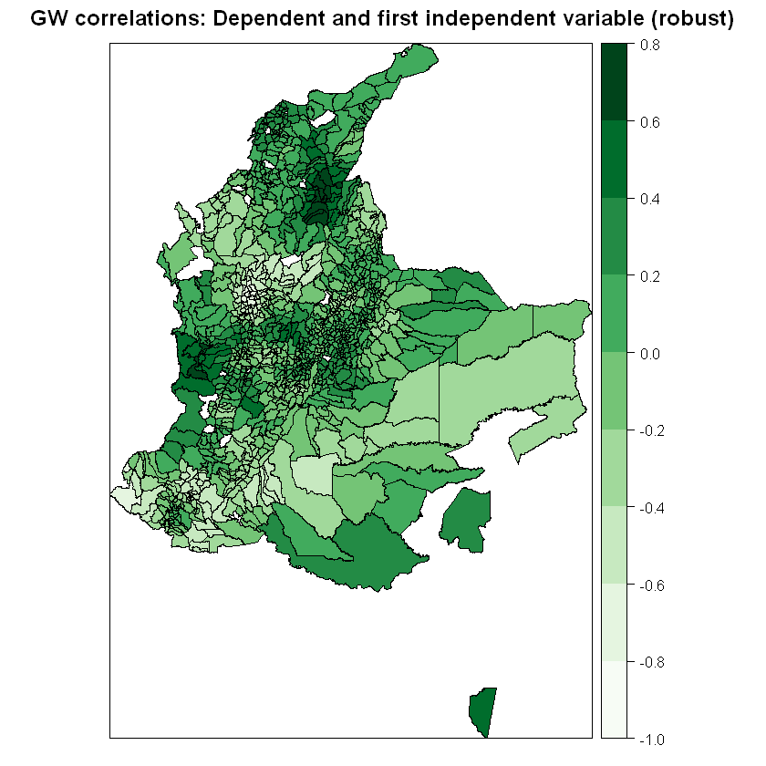

```r
# spplot(gw.ss.bs$SDF, "Spearman_rho_E_s11_to_1.MurderRate",key.space = "right",
#        col.regions = mypalette.3, at = c(-0.8, -0.6, -0.4, -0.2, 0, 0.2, 0.4, 0.6, 0.8, 1),
#        main = "GW correlations: SABER11 and Murder rate (robust)",
#        sp.layout = map.layout)
spplot(gw.ss.bs$SDF, SpeRhoDepVarIndVar1,key.space = "right",
       col.regions = mypalette.3, pretty=TRUE, cuts=8,
       main = "GW correlations: Dependent and first independent variable (robust)",
       sp.layout = map.layout)
```

Finally, the same is presented between the dependent and the third independent variable.

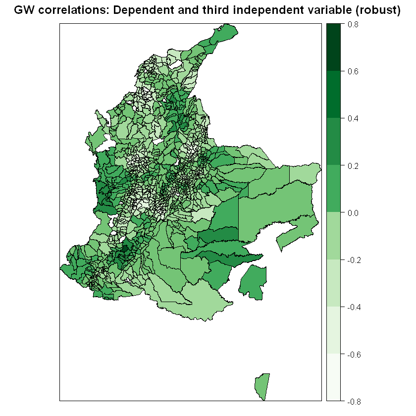

```r
# spplot(gw.ss.bs$SDF, "Spearman_rho_E_s11_to_1.Poverty",key.space = "right",
#        col.regions = mypalette.3, at = c(-0.8, -0.6, -0.4, -0.2, 0, 0.2, 0.4, 0.6, 0.8, 1),
#        main = "GW correlations: SABER11 and Poverty (robust)",
#        sp.layout = map.layout)
spplot(gw.ss.bs$SDF, SpeRhoDepVarIndVar3,key.space = "right",
       col.regions = mypalette.3, pretty=TRUE, cuts=8,
       main = "GW correlations: Dependent and third independent variable (robust)",
       sp.layout = map.layout)
```

```r
#bw.gwr.1 <- bw.gwr(whatever_theoretical_model_is_selected, data = PolygonShapeTrimmed, approach = "AICc",
#                   kernel = "bisquare", adaptive = TRUE)
bw.gwr.1 <- bw.gwr(as.formula(sorted.models[[1]][[length(sorted.models[[1]])]][[1]]), data = PolygonShapeTrimmed, approach = "AICc",
                   kernel = "bisquare", adaptive = TRUE)
cat("")
cat("The optimal adaptative bandwidth is equal to ", bw.gwr.1)
```

```
Adaptive bandwidth (number of nearest neighbours): 668 AICc value: 4797.465
Adaptive bandwidth (number of nearest neighbours): 421 AICc value: 4756.648
Adaptive bandwidth (number of nearest neighbours): 266 AICc value: 4755.709
Adaptive bandwidth (number of nearest neighbours): 173 AICc value: 4801.078
Adaptive bandwidth (number of nearest neighbours): 326 AICc value: 4750.123
Adaptive bandwidth (number of nearest neighbours): 361 AICc value: 4750.819
Adaptive bandwidth (number of nearest neighbours): 302 AICc value: 4751.859
Adaptive bandwidth (number of nearest neighbours): 338 AICc value: 4750.386
Adaptive bandwidth (number of nearest neighbours): 315 AICc value: 4750.466
Adaptive bandwidth (number of nearest neighbours): 329 AICc value: 4750.222
Adaptive bandwidth (number of nearest neighbours): 320 AICc value: 4750.076
Adaptive bandwidth (number of nearest neighbours): 320 AICc value: 4750.076
The optimal adaptative bandwidth is equal to  320
```

Once the adaptative bandwidth has been determined, and using the theoretical model determined by the pseudo stepwise procedure above, the Geographically Weighted Regressions are executed. As before, ff a strong theoretical model exists, and the last few steps were omitted, replace the corresponding formula on the commented out code snippled at the top.

Note that the option adaptative can be changes either to TRUE or to FALSE, with the resulting change in the way the regression is estimated. Also note that the kernel has been specified to be bisquare, but can be changed to be a number of possibilities, including gaussian, boxcar, exponential and tricube.

```r
#gwr.res <- gwr.basic(whatever_theoretical_model_is_selected, data = PolygonShapeTrimmed, bw = bw.gwr.1,
#                     kernel = "bisquare", adaptive = TRUE, F123.test = TRUE)

gwr.res <- gwr.basic(as.formula(sorted.models[[1]][[length(sorted.models[[1]])]][[1]]), data = PolygonShapeTrimmed, bw = bw.gwr.1,
                     kernel = "bisquare", adaptive = TRUE, F123.test = TRUE)
gwr.res
```

```
   *                       Package   GWmodel                             *
   Program starts at: 2021-09-06 18:20:38
   Call:
   gwr.basic(formula = as.formula(sorted.models[[1]][[length(sorted.models[[1]])]][[1]]),
    data = PolygonShapeTrimmed, bw = bw.gwr.1, kernel = "bisquare",
    adaptive = TRUE, F123.test = TRUE)

   Dependent (y) variable:  E_s11_to_1
   Independent variables:  Vulnerabil GC_discapi Lack_Respo Threat SISBEN1PC Poverty MurderRate HS_Cober_7 HS_Cober_1 TransEducP GC_indrura ProxyGDP G_IGA_tota TransAlimE
   Number of data points: 1070
   *                    Results of Global Regression                     *

   Call:
    lm(formula = formula, data = data)

   Residuals:
    Min      1Q  Median      3Q     Max
-7.9422 -1.6557 -0.0638  1.4837 10.8037

   Coefficients:
                 Estimate Std. Error t value Pr(>|t|)
   (Intercept)  4.564e+01  9.593e-01  47.582  < 2e-16 ***
   Vulnerabil  -6.474e-01  8.082e-02  -8.010 3.01e-15 ***
   GC_discapi   2.757e-04  1.494e-03   0.185   0.8536
   Lack_Respo  -5.360e-02  7.173e-02  -0.747   0.4551
   Threat       1.207e-01  5.724e-02   2.108   0.0353 *
   SISBEN1PC   -1.773e+01  3.871e+00  -4.580 5.20e-06 ***
   Poverty      4.197e-02  7.559e-03   5.552 3.56e-08 ***
   MurderRate  -1.156e-02  2.808e-03  -4.116 4.15e-05 ***
   HS_Cober_7   5.764e-03  3.870e-03   1.489   0.1367
   HS_Cober_1  -5.864e-03  3.409e-03  -1.720   0.0857 .
   TransEducP   5.273e-07  1.091e-06   0.483   0.6289
   GC_indrura   1.367e+00  4.869e-01   2.806   0.0051 **
   ProxyGDP     3.229e-01  1.293e-01   2.498   0.0127 *
   G_IGA_tota   6.908e-02  9.178e-03   7.527 1.11e-13 ***
   TransAlimE  -2.082e-04  4.513e-05  -4.613 4.46e-06 ***

   ---Significance stars
   Signif. codes:  0 '***' 0.001 '**' 0.01 '*' 0.05 '.' 0.1 ' ' 1
   Residual standard error: 2.458 on 1055 degrees of freedom
```

[output cut: 58 more lines]

```
   MurderRate      0.92235    126.41160            Inf    0.7230
   HS_Cober_7      1.78191    193.01631            Inf 1.390e-10 ***
   HS_Cober_1      2.12237    277.85263            Inf < 2.2e-16 ***
   TransEducP      1.33958     83.28561            Inf    0.0210 *
   GC_indrura      2.54794    308.48039            Inf < 2.2e-16 ***
   ProxyGDP        1.02305    111.16572            Inf    0.4148
   G_IGA_tota      1.69754    396.39560            Inf < 2.2e-16 ***
   TransAlimE      0.85819    224.95483            Inf    0.9394
   ---F4 test (GWR book p92)
    F4 statistic Numerator DF Denominator DF     Pr(>)
         0.63821    907.92654           1055 1.906e-12 ***

   ---Significance stars
   Signif. codes:  0 '***' 0.001 '**' 0.01 '*' 0.05 '.' 0.1 ' ' 1
   Program stops at: 2021-09-06 18:26:52
```

The names of the results are printed out, in case something wants to be produced with it. These same variables will be exported at the end of the code to a Shapefile, to be plotted and formatted on QGIS.

```r
writeOGR(gwr.res$SDF, "Data\\Colombia", driver="ESRI Shapefile", layer='Results', overwrite_layer = TRUE)
names(gwr.res$SDF)
```

1. 'Intercept'

2. 'Vulnerabil'

3. 'GC_discapi'

4. 'Lack_Respo'

5. 'Threat'

6. 'SISBEN1PC'

7. 'Poverty'

8. 'MurderRate'

9. 'HS_Cober_7'

10. 'HS_Cober_1'

11. 'TransEducP'

12. 'GC_indrura'

13. 'ProxyGDP'

14. 'G_IGA_tota'

15. 'TransAlimE'

16. 'y'

17. 'yhat'

18. 'residual'

19. 'CV_Score'

20. 'Stud_residual'

21. 'Intercept_SE'

22. 'Vulnerabil_SE'

23. 'GC_discapi_SE'

24. 'Lack_Respo_SE'

25. 'Threat_SE'

26. 'SISBEN1PC_SE'

27. 'Poverty_SE'

28. 'MurderRate_SE'

29. 'HS_Cober_7_SE'

30. 'HS_Cober_1_SE'

31. 'TransEducP_SE'

32. 'GC_indrura_SE'

33. 'ProxyGDP_SE'

34. 'G_IGA_tota_SE'

35. 'TransAlimE_SE'

36. 'Intercept_TV'

37. 'Vulnerabil_TV'

38. 'GC_discapi_TV'

39. 'Lack_Respo_TV'

40. 'Threat_TV'

41. 'SISBEN1PC_TV'

42. 'Poverty_TV'

43. 'MurderRate_TV'

44. 'HS_Cober_7_TV'

45. 'HS_Cober_1_TV'

46. 'TransEducP_TV'

47. 'GC_indrura_TV'

48. 'ProxyGDP_TV'

49. 'G_IGA_tota_TV'

50. 'TransAlimE_TV'

51. 'Local_R2'

A map of the coefficient estimates for the basic GWR estimation for the first independent variable is presented. An customizable example can be found for the first independent variable. The same thing is done for the other two independent variables in the example provided.

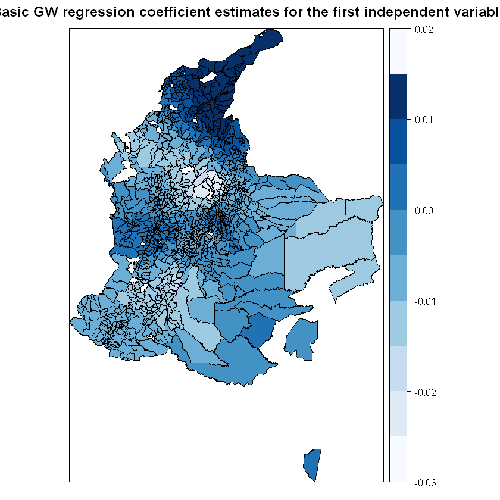

```r
#spplot(gwr.res$SDF, MurderRate, key.space = "right",
#       col.regions = mypalette.2, pretty=TRUE, cuts=8,
#       main = "Basic GW regression coefficient estimates for murder rates",
#       sp.layout = map.layout)
spplot(gwr.res$SDF, ListVariables[[2]], key.space = "right",
       col.regions = mypalette.2, pretty=TRUE, cuts=8,
       main = "Basic GW regression coefficient estimates for the first independent variable",
       sp.layout = map.layout)
```

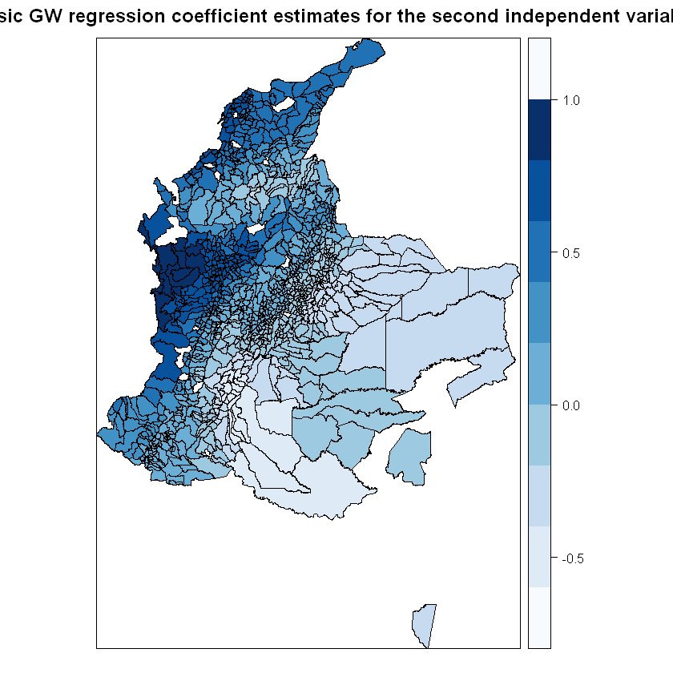

```r
spplot(gwr.res$SDF, ListVariables[[3]], key.space = "right",
       col.regions = mypalette.2, pretty=TRUE, cuts=8,
       main = "Basic GW regression coefficient estimates for the second independent variable",
       sp.layout = map.layout)
```

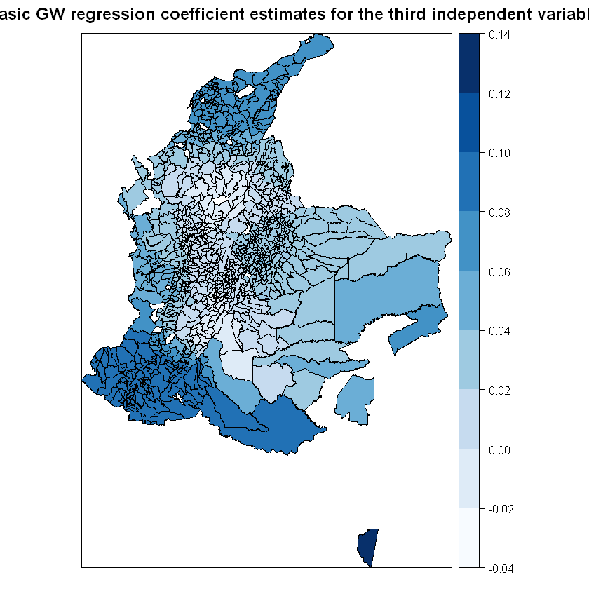

```r
spplot(gwr.res$SDF, ListVariables[[4]], key.space = "right",
       col.regions = mypalette.2, pretty=TRUE, cuts=8,
       main = "Basic GW regression coefficient estimates for the third independent variable",
       sp.layout = map.layout)
```

The same GWR regression, now calculating robust estimators, is performed. If the user has a strong model framework, it can be added in the commented out code snipplet. Note that his estimation is computationally expensive and can take a long time.

```r
#rgwr.res <- gwr.robust(as.formula(sorted.models[[1]][[length(sorted.models[[1]])]][[1]]), data = PolygonShapeTrimmed, bw = bw.gwr.1,
#                       kernel = "bisquare", adaptive = TRUE, F123.test = TRUE)
rgwr.res <- gwr.robust(as.formula(sorted.models[[1]][[length(sorted.models[[1]])]][[1]]), data = PolygonShapeTrimmed, bw = bw.gwr.1,
                       kernel = "bisquare", adaptive = TRUE, F123.test = TRUE)
rgwr.res
```

```
   *                       Package   GWmodel                             *
   Program starts at: 2021-09-06 20:13:27
   Call:
   gwr.basic(formula = formula, data = data, bw = bw, kernel = kernel,
    adaptive = adaptive, p = p, theta = theta, longlat = longlat,
    dMat = dMat, F123.test = F123.test, cv = T, W.vect = W.vect)

   Dependent (y) variable:  E_s11_to_1
   Independent variables:  Vulnerabil GC_discapi Lack_Respo Threat SISBEN1PC Poverty MurderRate HS_Cober_7 HS_Cober_1 TransEducP GC_indrura ProxyGDP G_IGA_tota TransAlimE
   Number of data points: 1070
   *                    Results of Global Regression                     *

   Call:
    lm(formula = formula, data = data)

   Residuals:
    Min      1Q  Median      3Q     Max
-7.9422 -1.6557 -0.0638  1.4837 10.8037

   Coefficients:
                 Estimate Std. Error t value Pr(>|t|)
   (Intercept)  4.564e+01  9.593e-01  47.582  < 2e-16 ***
   Vulnerabil  -6.474e-01  8.082e-02  -8.010 3.01e-15 ***
   GC_discapi   2.757e-04  1.494e-03   0.185   0.8536
   Lack_Respo  -5.360e-02  7.173e-02  -0.747   0.4551
   Threat       1.207e-01  5.724e-02   2.108   0.0353 *
   SISBEN1PC   -1.773e+01  3.871e+00  -4.580 5.20e-06 ***
   Poverty      4.197e-02  7.559e-03   5.552 3.56e-08 ***
   MurderRate  -1.156e-02  2.808e-03  -4.116 4.15e-05 ***
   HS_Cober_7   5.764e-03  3.870e-03   1.489   0.1367
   HS_Cober_1  -5.864e-03  3.409e-03  -1.720   0.0857 .
   TransEducP   5.273e-07  1.091e-06   0.483   0.6289
   GC_indrura   1.367e+00  4.869e-01   2.806   0.0051 **
   ProxyGDP     3.229e-01  1.293e-01   2.498   0.0127 *
   G_IGA_tota   6.908e-02  9.178e-03   7.527 1.11e-13 ***
   TransAlimE  -2.082e-04  4.513e-05  -4.613 4.46e-06 ***

   ---Significance stars
   Signif. codes:  0 '***' 0.001 '**' 0.01 '*' 0.05 '.' 0.1 ' ' 1
   Residual standard error: 2.458 on 1055 degrees of freedom
```

[output cut: 58 more lines]

```
   MurderRate       1.3368     126.4116            Inf 0.0068291 **
   HS_Cober_7       2.0497     193.0163            Inf  4.62e-16 ***
   HS_Cober_1       2.2588     277.8526            Inf < 2.2e-16 ***
   TransEducP       1.6790      83.2856            Inf 0.0001041 ***
   GC_indrura       2.1916     308.4804            Inf < 2.2e-16 ***
   ProxyGDP         1.4369     111.1657            Inf 0.0017537 **
   G_IGA_tota       1.8050     396.3956            Inf < 2.2e-16 ***
   TransAlimE       1.0996     224.9548            Inf 0.1457687
   ---F4 test (GWR book p92)
    F4 statistic Numerator DF Denominator DF     Pr(>)
         0.66786    910.17652           1055 1.991e-10 ***

   ---Significance stars
   Signif. codes:  0 '***' 0.001 '**' 0.01 '*' 0.05 '.' 0.1 ' ' 1
   Program stops at: 2021-09-06 20:19:39
```

The same maps presented above, but now for the robust version of the estimation, are computed below.

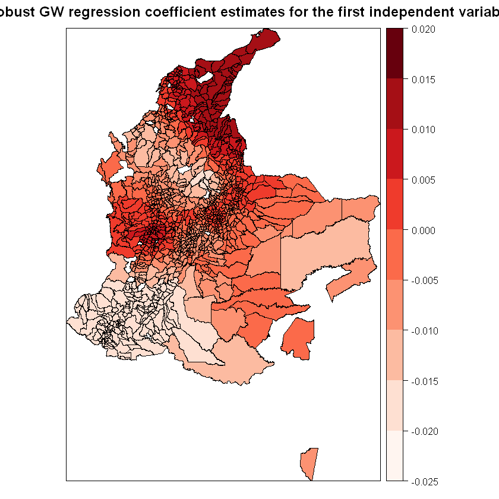

```r
spplot(rgwr.res$SDF, ListVariables[[2]], key.space = "right",
       col.regions = mypalette.1, pretty=TRUE, cuts=8,
       main = "Robust GW regression coefficient estimates for the first independent variable",
       sp.layout = map.layout)
```

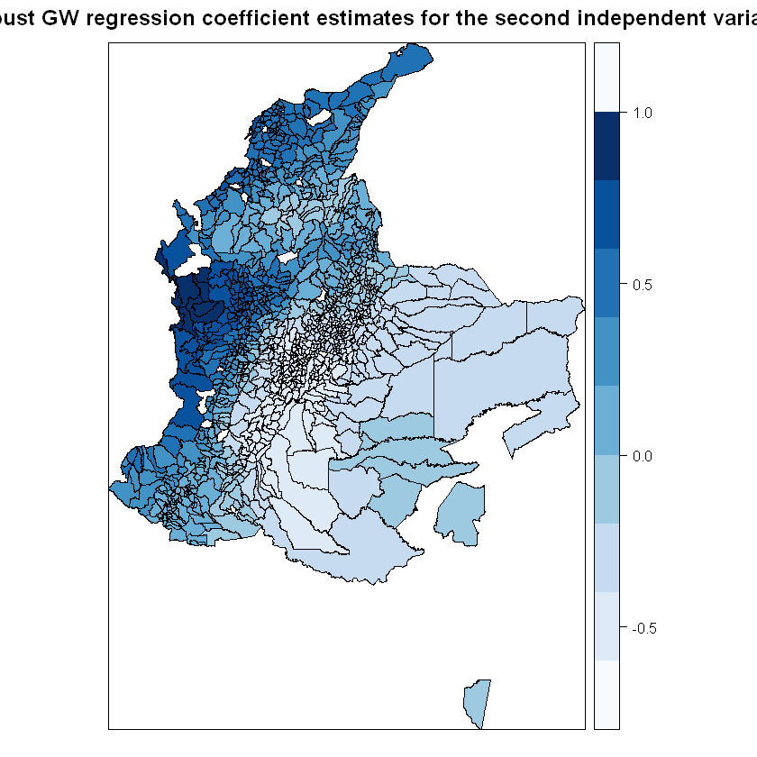

```r
spplot(rgwr.res$SDF, ListVariables[[3]], key.space = "right",
       col.regions = mypalette.2, pretty=TRUE, cuts=8,
       main = "Robust GW regression coefficient estimates for the second independent variable",
       sp.layout = map.layout)
```

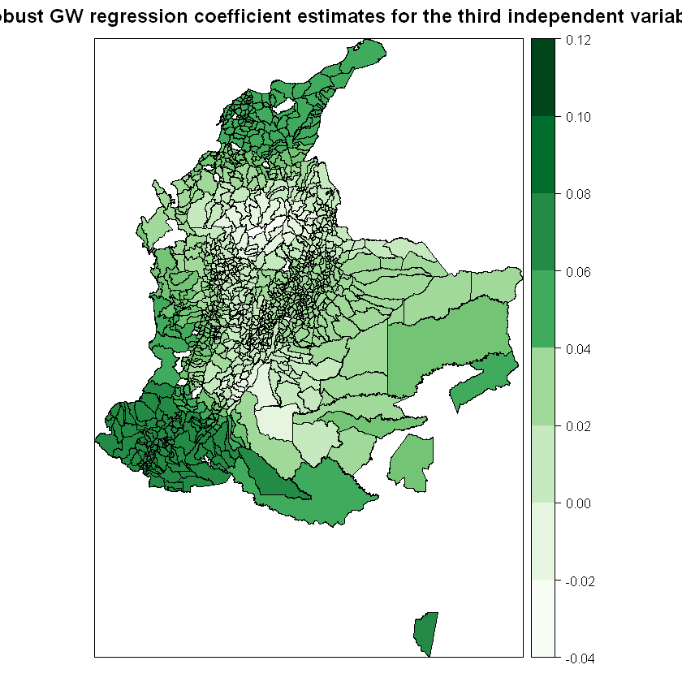

```r
spplot(rgwr.res$SDF, ListVariables[[4]], key.space = "right",
       col.regions = mypalette.3, pretty=TRUE, cuts=8,
       main = "Robust GW regression coefficient estimates for the third independent variable",
       sp.layout = map.layout)
```

Finally, the results from the estimations are exported as an ESRI Shapefile.

```r
writeOGR(rgwr.res$SDF, "Data\\Colombia", driver="ESRI Shapefile", layer='Results - Robust', overwrite_layer = TRUE)
```

End of the code.